# Prediction Assignment

Practical Machine Learning Coursera Data Science Specialization Course

## Summary

Machine learning algorithms were used to predict the classification as to the manner in which individuals performed a prescribed exercise. After data cleaning, Random Forests showed the highest estimated out-of-sample accuracy and was used to predict the classe variable for all 20 testing data set observations.

## Details

#### Initialize R Session

Load required libraries, set options, and set.seed for random number generation used in several machine learning algorithms.

```r
# load required packages
library(knitr)
library(data.table)
library(plyr)
library(dplyr)
library(caret)

# setup knitr
opts_chunk$set(warning=F, message=F, fig.width=10)
# set seed for repeatable results
set.seed(123456789)
```

#### Get data (if needed)

Data downloaded directly from the URLs presented as part of the project. Data is only download if it is not already within the environment.

```r
# data URLs
training.url <- 'https://d396qusza40orc.cloudfront.net/predmachlearn/pml-training.csv'
testing.url <- 'https://d396qusza40orc.cloudfront.net/predmachlearn/pml-testing.csv'

# get data if needed
if (!exists('training.raw')) {
  training.raw <- fread(training.url, sep=',', header=TRUE, stringsAsFactors=TRUE)
  testing.raw <- fread(testing.url, sep=',', header=TRUE, stringsAsFactors=TRUE)
}
```

#### Look at data summaries

After downloading the data, look at summary information about the data to see if there is any obvious data cleaning that must be done and/or if any structure in the data can be readily seen. Look at anything related to the training data set but DO NOT look directly at the test data set.

```r
dim(training.raw)
```

```
## [1] 19622   160
```

```r
summary(training.raw)
```

```
##        V1           user_name    raw_timestamp_part_1 raw_timestamp_part_2
##  1      :    1   adelmo  :3892   Min.   :1.322e+09    Min.   :   294
##  10     :    1   carlitos:3112   1st Qu.:1.323e+09    1st Qu.:252912
##  100    :    1   charles :3536   Median :1.323e+09    Median :496380
##  1000   :    1   eurico  :3070   Mean   :1.323e+09    Mean   :500656
##  10000  :    1   jeremy  :3402   3rd Qu.:1.323e+09    3rd Qu.:751891
##  10001  :    1   pedro   :2610   Max.   :1.323e+09    Max.   :998801
##  (Other):19616
##           cvtd_timestamp  new_window    num_window      roll_belt
##  28/11/2011 14:14: 1498   no :19216   Min.   :  1.0   Min.   :-28.90
##  05/12/2011 11:24: 1497   yes:  406   1st Qu.:222.0   1st Qu.:  1.10
##  30/11/2011 17:11: 1440               Median :424.0   Median :113.00
##  05/12/2011 11:25: 1425               Mean   :430.6   Mean   : 64.41
##  02/12/2011 14:57: 1380               3rd Qu.:644.0   3rd Qu.:123.00
##  02/12/2011 13:34: 1375               Max.   :864.0   Max.   :162.00
##  (Other)         :11007
##    pitch_belt          yaw_belt       total_accel_belt kurtosis_roll_belt
##  Min.   :-55.8000   Min.   :-180.00   Min.   : 0.00             :19216
##  1st Qu.:  1.7600   1st Qu.: -88.30   1st Qu.: 3.00    #DIV/0!  :   10
##  Median :  5.2800   Median : -13.00   Median :17.00    -1.908453:    2
##  Mean   :  0.3053   Mean   : -11.21   Mean   :11.31    -0.016850:    1
##  3rd Qu.: 14.9000   3rd Qu.:  12.90   3rd Qu.:18.00    -0.021024:    1
##  Max.   : 60.3000   Max.   : 179.00   Max.   :29.00    -0.025513:    1
##                                                        (Other)  :  391
##  kurtosis_picth_belt kurtosis_yaw_belt skewness_roll_belt
##           :19216            :19216              :19216
##  #DIV/0!  :   32     #DIV/0!:  406     #DIV/0!  :    9
##  47.000000:    4                       0.000000 :    4
##  -0.150950:    3                       0.422463 :    2
##  -0.684748:    3                       -0.003095:    1
##  -1.750749:    3                       -0.010002:    1
##  (Other)  :  361                       (Other)  :  389
##  skewness_roll_belt.1 skewness_yaw_belt max_roll_belt     max_picth_belt
##           :19216             :19216     Min.   :-94.300   Min.   : 3.00
##  #DIV/0!  :   32      #DIV/0!:  406     1st Qu.:-88.000   1st Qu.: 5.00
##  0.000000 :    4                        Median : -5.100   Median :18.00
##  -2.156553:    3                        Mean   : -6.667   Mean   :12.92
##  -3.072669:    3                        3rd Qu.: 18.500   3rd Qu.:19.00
##  -6.324555:    3                        Max.   :180.000   Max.   :30.00
##  (Other)  :  361                        NA's   :19216     NA's   :19216
```

[output cut: 313 more lines]

```
##  Min.   :-446.00   Min.   :-1280.0   Min.   :-896.0   Min.   :-973.0
##  1st Qu.:-182.00   1st Qu.: -616.0   1st Qu.:   2.0   1st Qu.: 191.0
##  Median : -39.00   Median : -378.0   Median : 591.0   Median : 511.0
##  Mean   : -55.29   Mean   : -312.6   Mean   : 380.1   Mean   : 393.6
##  3rd Qu.:  26.00   3rd Qu.:  -73.0   3rd Qu.: 737.0   3rd Qu.: 653.0
##  Max.   : 291.00   Max.   :  672.0   Max.   :1480.0   Max.   :1090.0
##
##  classe
##  A:5580
##  B:3797
##  C:3422
##  D:3216
##  E:3607
##
##
```

```r
dim(testing.raw)
```

```
## [1]  20 160
```

Note that the summary of the training.raw data presented above contains username (likely not useful if attempting to detect general features of the dataset, many “#DIV/0!” and “” (empty string) elements. Also, note the testing data set only contains 20 rows. Thus, the use of any time information seems not be useful as there are not enough samples in the testing data set.

#### Clean up data into a tidy data set

Now that there is an idea of what needs to be done to clean up the data sets, do it:

1. Remove seemingly meaningless variable
- username
- timestamps
2. Fix numeric cols - “” and “#DIV/0!” in what appears to be numeric variable
- replace with NA
- transform variable to numeric
- will leave most if not all variables as numeric
3. Remove columns with most if not all missing (NA) (really, any column with an NA in it)
4. Fix mistakes in variable names
5. Drop any other variables that do not seem important

The summary of the clean and tidy training data set is also presented.

NOTE: All cleaning steps HAVE to be performed on both the training and the testing data sets.

```r
# 1. Remove seemingly meaningless variable
rm.cols <- function(DT) {
  # if needed
  # remove V1 col (1st unnamed col which is just a row number)
  if ('V1' %in% colnames(DT))
    DT[,V1:=NULL]
  # remove uername, timestamps
  if ('user_name' %in% colnames(DT))
    DT[,user_name:=NULL]
  timestamp.cols <- grep('timestamp', colnames(DT), value=TRUE)
  if (any(grepl('timestamp', colnames(DT))))
    DT[,(timestamp.cols) := NULL]
}
# 2. Fix numeric cols -  "" and "#DIV/0!" in what appears to be numeric variable
fix.numeric.cols <- function(DT, values=c('', '#DIV/0!')) {
  # function to revalue factor field containing '' and '#DIV/0!' factor levels
  reval.and.as.numeric.col <- function(column) {
    if (any(values %in% levels(column)))
      as.numeric(mapvalues(column, from=values, to=rep(NA, length.out=length(values))))
    else
      column
  }
  # get cols to check then do it
  factor.vars <- which(sapply(DT, is.factor))
  if (length(factor.vars) > 0)
    DT[,(factor.vars):=lapply(.SD, reval.and.as.numeric.col), .SDcols=factor.vars]
}
# 3. Remove columns with most if not all missing (NA) (really, any column with an NA in it)
rm.cols.of.NAs <- function(DT) {
  col.has.na <- function(x) {
    any(is.na(x))
  }
  # get cols to drop, then drop them
  cols.drop <- which(sapply(DT, col.has.na))
  DT[,(cols.drop):=NULL]
}
# 4. Fix mistakes in variable names
fix.mispell.colnames <- function(DT) {
  # picth -> pitch via gsub
  colnames(DT) <- gsub('picth', 'pitch', colnames(DT))
}
# 5. Drop any other variables that do not seem important
drop.cols <- function(DT, cols) {
  DT[,(cols):=NULL]
}
# function to apply all to both sets
clean.data <- function() {
  rm.cols(training); rm.cols(testing)
  values <- c('', '#DIV/0!')
  fix.numeric.cols(training, values); fix.numeric.cols(testing, values)
  rm.cols.of.NAs(training); rm.cols.of.NAs(testing)
  fix.mispell.colnames(training); fix.mispell.colnames(testing)
  cols.to.drop <- grep('window', colnames(training), value=TRUE)
  drop.cols(training, cols.to.drop); drop.cols(testing, cols.to.drop)
}
# do it now
clean.data()
# show summary as well
summary(training)
```

```
##    roll_belt        pitch_belt          yaw_belt       total_accel_belt
##  Min.   :-28.90   Min.   :-55.8000   Min.   :-180.00   Min.   : 0.00
##  1st Qu.:  1.10   1st Qu.:  1.7600   1st Qu.: -88.30   1st Qu.: 3.00
##  Median :113.00   Median :  5.2800   Median : -13.00   Median :17.00
##  Mean   : 64.41   Mean   :  0.3053   Mean   : -11.21   Mean   :11.31
##  3rd Qu.:123.00   3rd Qu.: 14.9000   3rd Qu.:  12.90   3rd Qu.:18.00
##  Max.   :162.00   Max.   : 60.3000   Max.   : 179.00   Max.   :29.00
##   gyros_belt_x        gyros_belt_y       gyros_belt_z
##  Min.   :-1.040000   Min.   :-0.64000   Min.   :-1.4600
##  1st Qu.:-0.030000   1st Qu.: 0.00000   1st Qu.:-0.2000
##  Median : 0.030000   Median : 0.02000   Median :-0.1000
##  Mean   :-0.005592   Mean   : 0.03959   Mean   :-0.1305
##  3rd Qu.: 0.110000   3rd Qu.: 0.11000   3rd Qu.:-0.0200
##  Max.   : 2.220000   Max.   : 0.64000   Max.   : 1.6200
##   accel_belt_x       accel_belt_y     accel_belt_z     magnet_belt_x
##  Min.   :-120.000   Min.   :-69.00   Min.   :-275.00   Min.   :-52.0
##  1st Qu.: -21.000   1st Qu.:  3.00   1st Qu.:-162.00   1st Qu.:  9.0
##  Median : -15.000   Median : 35.00   Median :-152.00   Median : 35.0
##  Mean   :  -5.595   Mean   : 30.15   Mean   : -72.59   Mean   : 55.6
##  3rd Qu.:  -5.000   3rd Qu.: 61.00   3rd Qu.:  27.00   3rd Qu.: 59.0
##  Max.   :  85.000   Max.   :164.00   Max.   : 105.00   Max.   :485.0
##  magnet_belt_y   magnet_belt_z       roll_arm         pitch_arm
##  Min.   :354.0   Min.   :-623.0   Min.   :-180.00   Min.   :-88.800
##  1st Qu.:581.0   1st Qu.:-375.0   1st Qu.: -31.77   1st Qu.:-25.900
##  Median :601.0   Median :-320.0   Median :   0.00   Median :  0.000
##  Mean   :593.7   Mean   :-345.5   Mean   :  17.83   Mean   : -4.612
##  3rd Qu.:610.0   3rd Qu.:-306.0   3rd Qu.:  77.30   3rd Qu.: 11.200
##  Max.   :673.0   Max.   : 293.0   Max.   : 180.00   Max.   : 88.500
##     yaw_arm          total_accel_arm  gyros_arm_x        gyros_arm_y
##  Min.   :-180.0000   Min.   : 1.00   Min.   :-6.37000   Min.   :-3.4400
##  1st Qu.: -43.1000   1st Qu.:17.00   1st Qu.:-1.33000   1st Qu.:-0.8000
##  Median :   0.0000   Median :27.00   Median : 0.08000   Median :-0.2400
##  Mean   :  -0.6188   Mean   :25.51   Mean   : 0.04277   Mean   :-0.2571
##  3rd Qu.:  45.8750   3rd Qu.:33.00   3rd Qu.: 1.57000   3rd Qu.: 0.1400
##  Max.   : 180.0000   Max.   :66.00   Max.   : 4.87000   Max.   : 2.8400
##   gyros_arm_z       accel_arm_x       accel_arm_y      accel_arm_z
##  Min.   :-2.3300   Min.   :-404.00   Min.   :-318.0   Min.   :-636.00
##  1st Qu.:-0.0700   1st Qu.:-242.00   1st Qu.: -54.0   1st Qu.:-143.00
##  Median : 0.2300   Median : -44.00   Median :  14.0   Median : -47.00
##  Mean   : 0.2695   Mean   : -60.24   Mean   :  32.6   Mean   : -71.25
```

[output cut: 50 more lines]

```
##  Max.   :311.00000   Max.   :231.0000   Max.   : 477.00   Max.   : 923.0
##  accel_forearm_z   magnet_forearm_x  magnet_forearm_y magnet_forearm_z
##  Min.   :-446.00   Min.   :-1280.0   Min.   :-896.0   Min.   :-973.0
##  1st Qu.:-182.00   1st Qu.: -616.0   1st Qu.:   2.0   1st Qu.: 191.0
##  Median : -39.00   Median : -378.0   Median : 591.0   Median : 511.0
##  Mean   : -55.29   Mean   : -312.6   Mean   : 380.1   Mean   : 393.6
##  3rd Qu.:  26.00   3rd Qu.:  -73.0   3rd Qu.: 737.0   3rd Qu.: 653.0
##  Max.   : 291.00   Max.   :  672.0   Max.   :1480.0   Max.   :1090.0
##  classe
##  A:5580
##  B:3797
##  C:3422
##  D:3216
##  E:3607
##
```

#### Explore data

Now that there is a clean data set to explore and start building a prediction model with, take a look at a few potential features.

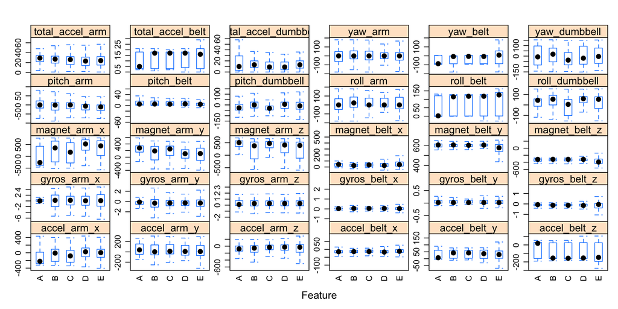

```r
featurePlot(x=training[,1:30, with=F],
  y=training$classe,
  plot = "box",
  ## Pass in options to bwplot()
  scales = list(y = list(relation="free"),
              x = list(rot = 90)),
  layout = c(6,5),
  do.out=FALSE,
  auto.key = list(columns = 5)
)
```

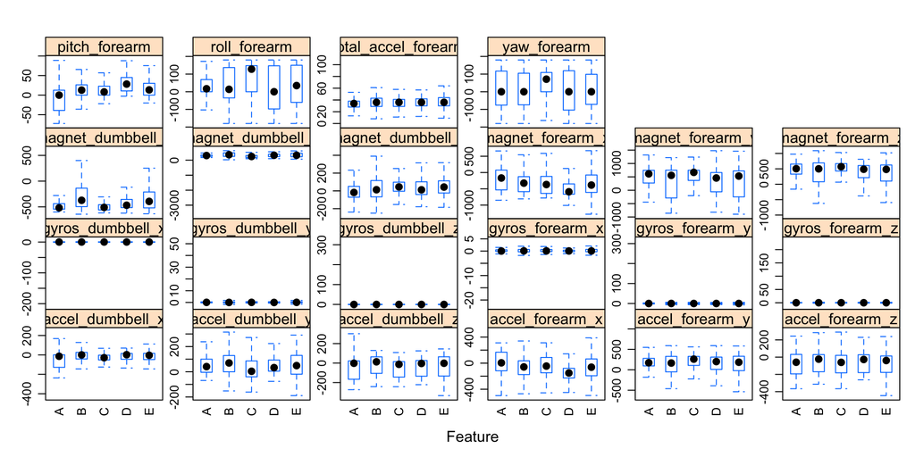

```r
featurePlot(x=training[,31:52, with=F],
  y=training$classe,
  plot = "box",
  ## Pass in options to bwplot()
  scales = list(y = list(relation="free"),
              x = list(rot = 90)),
  layout = c(6,4),
  do.out=FALSE,
  auto.key = list(columns = 5)
)
```

#### Setup Cross Validation

In order to allow for a reasonable estimate of the out-of-sample error rate, use 3-fold cross validation within the train function in generating the model. Reported accuracy will then be a reasonable estimate of the out-of-sample error rate.

```r
# setup cross validation
# try 3-fold cross validation
train.control <- trainControl(method='cv', number=3, allowParallel = TRUE)
```

#### Generate and evaluate classification models with all variables

Since classe is a factor variable with 5 levels (A, B, C, D, E) classification based machine learning algorithms must be employed. The algorithms employed in this project include random forests (rf), naive Bayes (nb), stochastic gradient boosting (gbm), CART (rpart) and k-nearest neighbors (knn). All variables left after data cleaning are used as features without additional processing in each model. All classification models are generated below and evaluated in the next section. To reduce computational time, the models are evaluated only if they do not currently exist.

1. Random Forest (rf)

```r
if (!exists('rf.model')) {
  rf.model <- train(classe ~ ., data=training, trControl=train.control,
    method='rf', prox=TRUE, importance = TRUE)
  rf.predictions <- predict(rf.model, newdata=training)
  rf.confusMat <- confusionMatrix(rf.predictions, training$classe)
}
```

2. Naive Bayes (nb)

```r
if (!exists('nb.model')) {
  nb.model <- train(classe ~ ., data=training, trControl=train.control,
    method='nb', importance = TRUE)
  nb.predictions <- predict(nb.model, newdata=training)
  nb.confusMat <- confusionMatrix(nb.predictions, training$classe)
}
```

3. Stochastic Gradient Boosting (gbm)

```r
if (!exists('gbm.model')) {
  gbm.model <- train(classe ~ ., data=training, trControl=train.control,
    method='gbm', verbose=FALSE)
  gbm.predictions <- predict(gbm.model, newdata=training)
  gbm.confusMat <- confusionMatrix(gbm.predictions, training$classe)
}
```

4. CART (rpart)

```r
if (!exists('rpart.model')) {
  rpart.model <- train(classe ~ ., data=training, trControl=train.control,
    method='rpart')
  rpart.predictions <- predict(rpart.model, newdata=training)
  rpart.confusMat <- confusionMatrix(rpart.predictions, training$classe)
}
```

5. k-Nearest Neighbors (knn)

```r
if (!exists('knn.model')) {
  knn.model <- train(classe ~ ., data=training, trControl=train.control,
    method='knn')
  knn.predictions <- predict(knn.model, newdata=training)
  knn.confusMat <- confusionMatrix(knn.predictions, training$classe)
}
```

#### Classification model performance

The performance (as estimated out-of-sample accuracy since 3-fold cross validation was used) of each model on the training data set is presented below:

```r
# put models in a list to use *ply functions to get results out
models <- list(rf=rf.model, nb=nb.model, gbm=gbm.model, rpart=rpart.model, knn=knn.model)
# get max accuracy (will also be used as finalModel in any predict function)
max.accuracy <- sapply(models, function(x) {max(x$results$Accuracy)})
# show results
max.accuracy
```

```
##        rf        nb       gbm     rpart       knn
## 0.9935277 0.7415138 0.9624401 0.5118249 0.9054123
```

Random forests demonstrated the best performance with an estimated out-of-sample accuracy of 99.3527652% with stochastic gradient boosting (gbm) a close second. The best and final model generated by Random Forests was used to predict the classe of each observation in the testing data set.

#### Variables of importance

Random forests can also be used to identify which variables are important to classifying each observation of the training data set as part of its algorithm. The top 20 variables for each classe are shown below.

```r
varImp(rf.model)
```

```
## rf variable importance
##
##   variables are sorted by maximum importance across the classes
##   only 20 most important variables shown (out of 52)
##
##                       A     B     C     D      E
## roll_belt         78.70 80.99 83.57 75.17 100.00
## pitch_forearm     57.05 77.68 97.59 55.41  64.10
## pitch_belt        26.82 93.12 58.92 45.69  37.40
## magnet_dumbbell_y 64.77 68.55 89.91 63.85  56.10
## magnet_dumbbell_z 73.97 57.91 71.38 47.88  51.57
## yaw_belt          55.80 67.12 66.04 72.42  49.49
## roll_forearm      49.81 40.14 47.61 33.42  36.46
## accel_forearm_x   17.52 39.79 33.23 47.88  36.52
## gyros_belt_z      22.71 30.14 31.44 21.58  40.93
## gyros_dumbbell_y  33.63 26.93 39.24 25.11  23.25
## yaw_arm           38.69 31.09 25.91 30.76  18.00
## accel_dumbbell_y  33.14 30.55 37.96 26.94  29.89
## accel_dumbbell_z  22.52 29.79 19.99 26.07  36.56
## roll_dumbbell     19.33 32.75 18.24 22.13  28.58
## magnet_belt_x     10.64 29.61 24.20 17.18  29.99
## magnet_forearm_z  28.50 27.37 26.83 24.08  29.85
## gyros_arm_y       24.25 29.83 25.22 29.13  20.86
## magnet_arm_z      14.65 29.35 19.47 18.61  17.85
## magnet_belt_z     16.60 29.29 21.24 24.93  22.45
## magnet_belt_y     12.43 29.08 24.03 16.59  23.18
```

This list of variable importance could be used to limit the variables used in future analysis. However, this type of model refinement was viewed to be outside the scope of this project.

#### Predictions on the testing data set

The Random Forests model generated above was used to predict the classe classification for all observations in the testing data set (which was also cleaned in exactly the same manner as the training data set).

```r
# predict using the Random Forests model
predictions <- predict(rf.model, newdata=testing)
# shown them along with case number (to facilitate the quiz)
data.frame(N=1:length(predictions), predicted.classe=predictions)
```

```
##     N predicted.classe
## 1   1                B
## 2   2                A
## 3   3                B
## 4   4                A
## 5   5                A
## 6   6                E
## 7   7                D
## 8   8                B
## 9   9                A
## 10 10                A
## 11 11                B
## 12 12                C
## 13 13                B
## 14 14                A
## 15 15                E
## 16 16                E
## 17 17                A
## 18 18                B
## 19 19                B
## 20 20                B
```